# Molecular Marker Assisted Plant Breeding

Statistical Power associated to GWAS

Felipe Ferrão

University of Florida

**Objectives:**

- 60 minutes of hands-on
- Introduction to statistical power in GWAS
- Running simple simulations in R

**Extra information**

- [HOS 6236 – Website](https://lfelipe-ferrao.github.io/class/mas/)
- About the [author](https://lfelipe-ferrao.github.io/)
- About the [UF/IFAS Plant Breeding](https://programs.ifas.ufl.edu/plant-breeding/)

# Introduction

When designing a GWAS experiment, one of the central questions we must address is: **What are the key factors that influence the outcomes of my GWAS results?** Statistically, this question can be framed in terms of statistical power—that is, the ability to detect true associations between genetic variants and the trait of interest. In this class, we will explore the underlying principles of p-value computation in GWAS and examine the main factors that influence it, including sample size, effect size, allele frequency, and error variance.

# Statistical test

## The p.value behind of the manhattan plots

Most GWAS results are presented using Manhattan plots, which display the distribution of −log10(p-value) across the chromosomes. **The p-value is used to assess whether the observed data are inconsistent with the null hypothesis.** Typically, the null hypothesis states that a given variant (or the SNP effect estimated from the GWAS model) has no effect—that is, its effect size is zero. Since we test each variant individually, there is one null hypothesis per variant.

The p-value represents the probability of observing data “at least as extreme” as what we have, assuming the null hypothesis is true. Intuitively, we can divide our decisions into:

- Small p-value is considered evidence against the null hypothesis, i.e, it is unlikely to observe such data under the null hypothesis and therefore it is a rare event.
- Large p-value is evidence in favor of the null hypothesis.

In summary, the p-value will be **a numerical measure of how consistent the data are with the null hypothesis**. However, it is important to emphasize that the p-value is **not the probability that the null hypothesis is true**; rather, it is the probability of observing the data (or something more extreme) given that the null hypothesis holds.

Let’s assume the following linear regression:

$$y= \mu + x\beta + e$$

- $H_0: \beta = 0$
- We can test the hypothesis using t-statistics: $t=\dfrac{\hat{\beta}}{SE}$, where $t(n-2)$ degree of freedom.
- The t-distribution could be approximate to a standard normal distribution $N(0,1)$ , and therefore could be called as z-score as shown below.

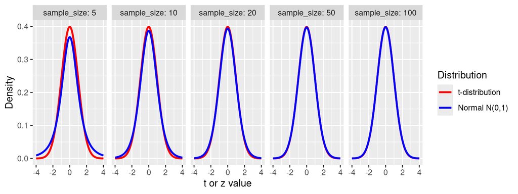

- The other way to express the same normal approximation is to say that the square of the t-statistic follows a chi-square distribution with 1 degree of freedom: $t^2 \sim \chi^2$.

[figure not shown]

## Statistical Power

### Distributions

**Why Is It Important to Understand the Relationship Between the *t*-Distribution, the Normal Distribution, and the Chi-Square Distribution?**

As we move forward in this class, we will introduce the concept of **statistical power** and derive equations that illustrate how changes in key components of a GWAS experiment can influence our ability to detect significant genetic associations.

To achieve this, we need to introduce the concept of the **non-centrality parameter (NCP)**, which plays a critical role in power analysis based on the chi-square distribution.

**Connecting Effect Estimates to Statistical Distributions**

$$\hat{\beta} \sim \mathcal{N}(\beta,
SE^2)$$

The $\beta$ here represented is the theoretical true effect size and SE the standard error of the estimators. If the $\beta=0$, or in another words, the marker is not associated to the phenotype, it follow under the null hypothesis and the z-score (or $t=\dfrac{\hat{\beta}}{SE}$) is distributed as $z \sim N (0,1)$. From the last section, we know that this can be approximated to a chi-square distribution.

If the $\beta \neq 0$, there is is evidence that the marker is associated to the phenotype, it is distributed as $z \sim N (\beta/SE,1)$ and the $z^2 \sim \chi^2 (\beta/SE)^2)$.

Here is where we need to arrive:

- When $\beta = 0$, the null hypothesis reduces to a standard central chi-square distribution
- If $\beta \neq 0$ is driven by a chi-square distribution with 1 degree of freedom and a non-centrality parameter given by $NCP=(\beta/SE)^2$

Look the example below:

- We visualize the **Z-score distributions** corresponding to four different effect sizes (β values). The black curve represents the **null hypothesis** scenario where the true effect size is zero (β = 0). The other colored curves represent scenarios under the **alternative hypothesis** where β takes on positive values (e.g., 1, 2, or 3), indicating increasing true effect sizes.
- Notice how the Z-score distribution shifts its mean as the effect size increases. Under the null hypothesis, the Z-scores follow a standard normal distribution centered at zero. Under the alternative hypothesis, the distribution is centered at the true effect size scaled by its standard error, resulting in a shift away from zero.
- Importantly, the Z-score can be converted into a **chi-square statistic** by squaring it. This transformation changes the distribution from a symmetric normal distribution to a right-skewed chi-square distribution with 1 degree of freedom.
- Observe in the plots how, under the null hypothesis (β = 0), the chi-square distribution is the classic central chi-square distribution with a peak near zero.
- When moving away from the null hypothesis (β > 0), the chi-square distribution becomes a **non-central chi-square distribution**, characterized by a **non-centrality parameter (NCP)**
- The larger the true effect size, the greater the NCP, and the more the chi-square distribution deviates from the null. This shift is what enables statistical tests to detect associations: a higher NCP generally means greater **statistical power** to reject the null hypothesis.

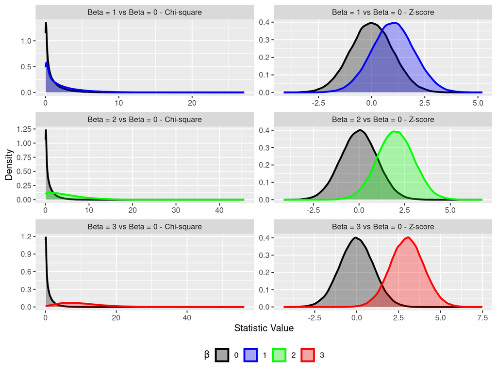

### The Statistical Power Equation

**Statistical power** is the probability of correctly rejecting the null hypothesis (detecting a true association) when an effect truly exists. In the context of GWAS, power depends largely on the **Non-Centrality Parameter (NCP)** of the test statistic’s distribution under the alternative hypothesis.

- Recall that the GWAS test statistic (e.g., the chi-square test) under the alternative hypothesis follows a **non-central chi-square distribution** with 1 degree of freedom and non-centrality parameter $\text{NCP}$.
- The NCP quantifies the degree to which the alternative distribution deviates from the null distribution, reflecting the **signal strength** relative to noise.

The NCP for a single SNP association test can be expressed as:

$$NCP = N \times \frac{2p(1-p) \beta^2}{\sigma^2}$$

Where:

- $N$ = sample size
- $p$ = minor allele frequency (MAF)
- $\beta$ = true SNP effect size
- $\sigma^2$ = phenotypic variance (including residual variance)

[figure not shown]

**In summary**

- Sample size: sample size is most clearly under the control of study design. Increasing sample size increases power because it increases accuracy of effect size estimate.
- Effect size: increasing the absolute value of effect size increases power because it increases difference from the null model.
- Minor allele frequency: increasing MAF increases power because it increases accuracy of effect size estimate.

# Hands-on

## Simulated data set

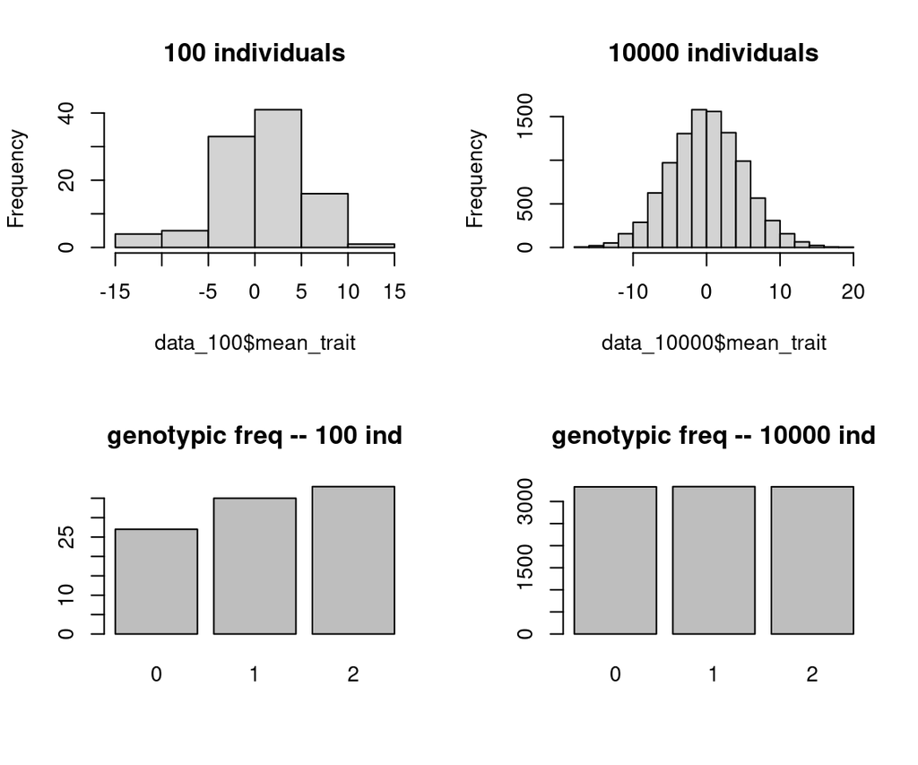

```r
# Load libraries
library(ggplot2)
library(dplyr)
library(gridExtra)

set.seed(12345)
# Function to simulate data
simulate_data <- function(n, afreq, b) {
  genotypes <- sample(0:2, n, replace = TRUE)
  epsilon <- rnorm(n, mean = 0, sd = 5)
  mean_trait <- afreq * b * genotypes + epsilon
  data.frame(genotype = genotypes, mean_trait = mean_trait)
}

# Parameters
afreq <- 0.5
b <- 0.2

# Simulate data
data_100 <- simulate_data(100, afreq, b)
data_10000 <- simulate_data(10000, afreq, b)

# Graphical analysis
par(mfrow=c(2,2))
hist(data_100$mean_trait, main="100 individuals")
hist(data_10000$mean_trait, main="10000 individuals")
barplot(table(data_100$genotype), main="genotypic freq -- 100 ind")
barplot(table(data_10000$genotype), main="genotypic freq -- 10000 ind")
```

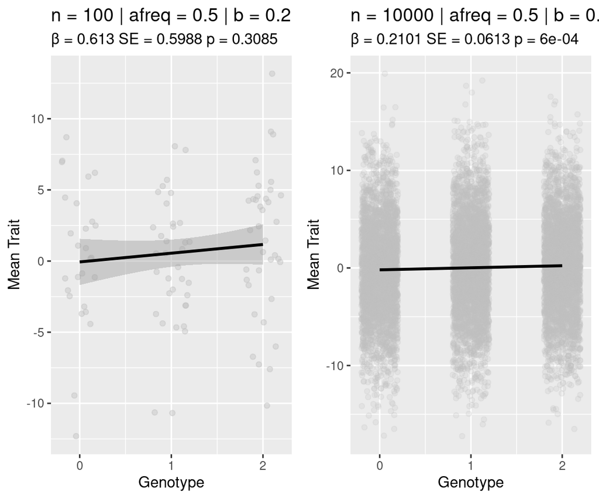

```r
# Fit models
lm_100 <- lm(mean_trait ~ genotype, data = data_100)
lm_10000 <- lm(mean_trait ~ genotype, data = data_10000)
# summary(lm_100)
# summary(lm_10000)

# Plot n = 100
plot_100 <- ggplot(data_100, aes(x = genotype, y = mean_trait)) +
  geom_jitter(width = 0.2, alpha = 0.4, color = "gray") +  # Optional jitter for visibility
  geom_smooth(method = "lm", se = TRUE, color = "black") +
  scale_x_continuous(breaks = 0:2) +
  labs(
    title = "n = 100 | afreq = 0.5 | b = 0.2",
    subtitle = paste("β =", round(coef(lm_100)[2], 4),
                     "SE =", round(summary(lm_100)$coefficients[2, 2], 4),
                     "p =", round(summary(lm_100)$coefficients[2, 4], 4)),
    x = "Genotype", y = "Mean Trait"
  )

# Plot n = 10000
plot_10000 <- ggplot(data_10000, aes(x = genotype, y = mean_trait)) +
  geom_jitter(width = 0.2, alpha = 0.2, color = "gray") +
  geom_smooth(method = "lm", se = TRUE, color = "black") +
  scale_x_continuous(breaks = 0:2) +
  labs(
    title = "n = 10000 | afreq = 0.5 | b = 0.2",
    subtitle = paste("β =", round(coef(lm_10000)[2], 4),
                     "SE =", round(summary(lm_10000)$coefficients[2, 2], 4),
                     "p =", round(summary(lm_10000)$coefficients[2, 4], 4)),
    x = "Genotype", y = "Mean Trait"
  )

# Show plots side by side
grid.arrange(plot_100, plot_10000, ncol = 2)
```

## Simulation Statistical Power

The `genpwr` package performs power and sample size calculations for genetic association studies, considering the impact of misspecification of the genetic model.

Below, an example:

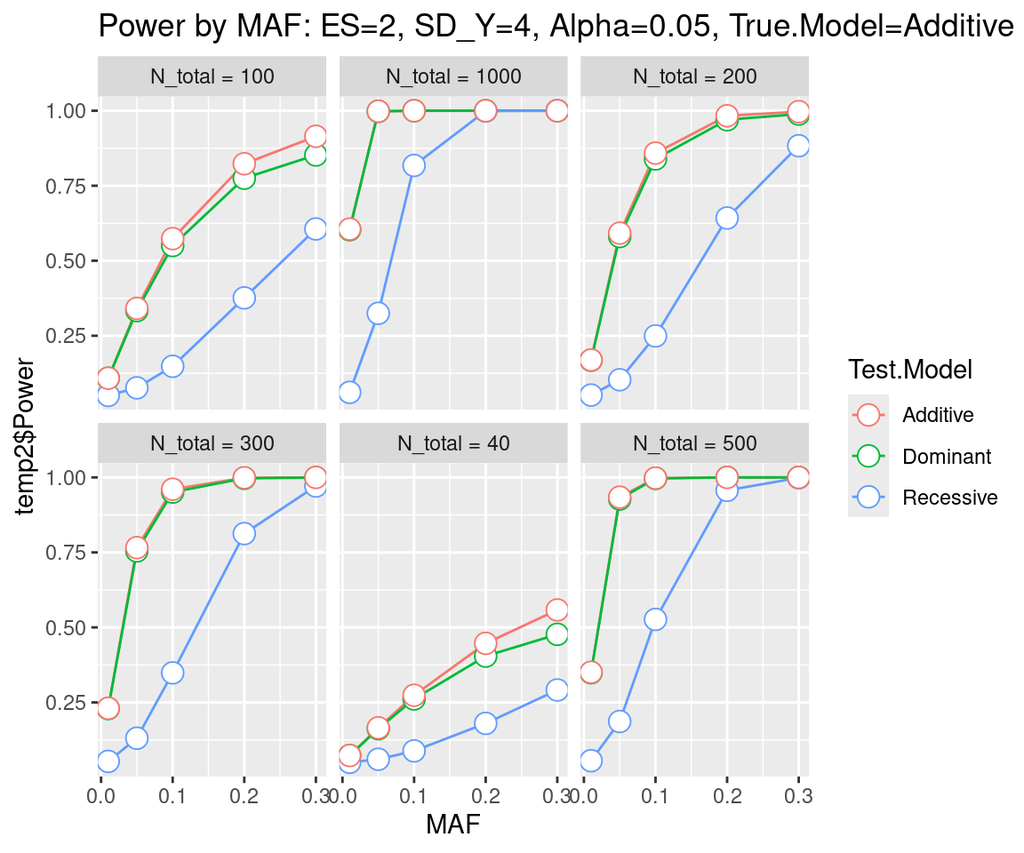

```r
library(genpwr)

pw <- genpwr.calc(calc = "power", model = "linear",
   N=c(40,100,200,300,500,1000), sd_y=4, k=NULL,
   MAF=c(0.01, 0.05, 0.10, 0.2, 0.3), ES=c(2),Alpha=0.05,
   True.Model=c("Additive"),
   Test.Model=c("Dominant", "Recessive", "Additive"))
power.plot(pw,panel.by="N_total")
```

# Conclusion

The theoretical results presented in this section — particularly the influence of sample size, effect size, allele frequency, and significance threshold on statistical power — offer a concrete framework to guide the design of effective GWAS studies.

Before setting up a GWAS experiment, several practical and theoretical questions should be considered, rooted in **statistical power theory**:

1. Is there any preliminary GWAS study for this trait in my species?
2. Is my trait likely controlled by rare or common variants?
3. Do we have any prior estimates of marker effect sizes?
4. What population sizes are typically used in similar GWAS?

Understanding power in the GWAS context is about ensuring that the design of your experiment maximizes the likelihood of detecting **true genetic associations**, while controlling for **false positives**. Statistical power depends on four main factors:

| Factor | Influence |
| --- | --- |
| **Sample Size (n)** | Increases power linearly through the NCP |
| **Effect Size (β)** | Larger effects are easier to detect |
| **Minor Allele Frequency (p)** | Power is maximized when $p \approx 0.5$; drops with rare alleles |
| **Significance Threshold (α)** | Lower thresholds (e.g., 5e-8) reduce power but control false positives |

# References

- [Klein (1997)](https://bmcgenomdata.biomedcentral.com/articles/10.1186/1471-2156-8-58). Power analysis for genome-wide association studies. BMC Genomic Data
- [Moore et al., (2019)](https://karger.com/hhe/article-abstract/84/6/256/161350/Power-and-Sample-Size-Calculations-for-Genetic?redirectedFrom=fulltext). Power and Sample Size Calculations for Genetic Association Studies in the Presence of Genetic Model Misspecification. Human Heredity.